# Logistic regression

## What I learned this week

This week I learned about logistic regression..

## Data exploration and selection

Let’s start by reading in the data and exploring the structure and dimensions of the data:

```r
#read in the csv
alc<-read.csv("C:/Users/Sirke Piirainen/Documents/GitHub/IODS-project/data/alc.csv",header = T)

#print the names of the columns
names(alc)
```

```
##  [1] "school"     "sex"        "age"        "address"    "famsize"
##  [6] "Pstatus"    "Medu"       "Fedu"       "Mjob"       "Fjob"
## [11] "reason"     "nursery"    "internet"   "guardian"   "traveltime"
## [16] "studytime"  "failures"   "schoolsup"  "famsup"     "paid"
## [21] "activities" "higher"     "romantic"   "famrel"     "freetime"
## [26] "goout"      "Dalc"       "Walc"       "health"     "absences"
## [31] "G1"         "G2"         "G3"         "alc_use"    "high_use"
```

This data consists of student achievements in secondary education of two Portuguese schools. The data attributes include student grades (G1, G2 and G3), demographic, social and school related features and it was collected by using school reports and questionnaires. Two datasets were provided regarding the performance in two distinct subjects: Mathematics (mat) and Portuguese language (por). These datasets have been combined so that numerical variables are averaged and categorical values are taken directly from the Mathematics dataset. Alcohol consumption of students during week days and weekends has been combined as an average and categorized yes or no for high use. Check the variable details [here](https://archive.ics.uci.edu/ml/datasets/Student+Performance).

The data consists of 35 variables and 382 observations.

Next I want to study the relationships between high/low alcohol consumption and some of the other variables in the data. To do this, I choose 4 interesting variables in the data and for each of them, I present a hypothesis about their relationships with alcohol consumption.

1. famrel - quality of family relationships (numeric: from 1 - very bad to 5 - excellent) I assume students with very bad realationships have high alcohol consumption.
2. absences - number of school absences (numeric: from 0 to 93) I assume student with lots of absences have high alcohol consumption.
3. studytime - weekly study time (numeric: 1 - <2 hours, 2 - 2 to 5 hours, 3 - 5 to 10 hours, or 4 - >10 hours) I assume that students with low weekly study time have high alcohol consumption.
4. higher - wants to take higher education (binary: yes or no) I assume students who don’t want to take higher education have high alcohol consumption.

```r
#get some packages
library(tidyr); library(dplyr); library(ggplot2)
#select only the data that I am interested in
choose<-c("high_use","famrel","absences","studytime","higher")
alc2<-select(alc,one_of(choose))

#summary table of the data
summary(alc2)
```

```
##   high_use           famrel         absences      studytime     higher
##  Mode :logical   Min.   :1.000   Min.   : 0.0   Min.   :1.000   no : 18
##  FALSE:268       1st Qu.:4.000   1st Qu.: 1.0   1st Qu.:1.000   yes:364
##  TRUE :114       Median :4.000   Median : 3.0   Median :2.000
##                  Mean   :3.937   Mean   : 4.5   Mean   :2.037
##                  3rd Qu.:5.000   3rd Qu.: 6.0   3rd Qu.:2.000
##                  Max.   :5.000   Max.   :45.0   Max.   :4.000
```

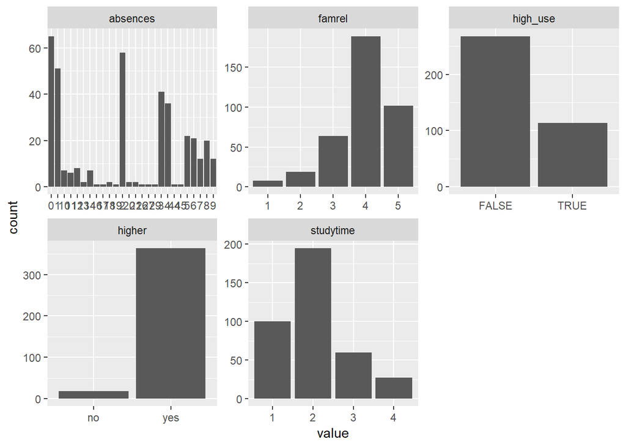

```r
#draw barplots of variables to study their distribution
gather(alc2) %>% ggplot(aes(value)) + facet_wrap("key", scales = "free")+geom_bar()
```

None of the variables seem to be evenly distributed.

```r
library(GGally)
```

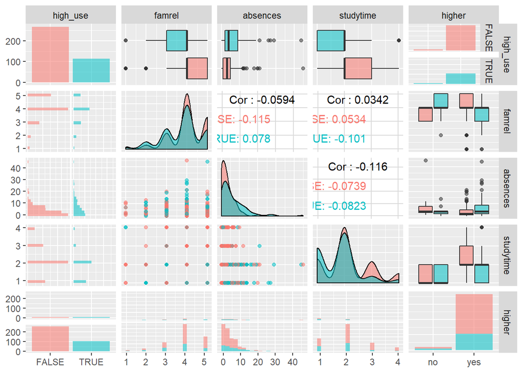

```r
# create a plot matrix with ggpairs()
p <- ggpairs(alc2, mapping = aes(col=high_use,alpha=0.3), lower = list(combo = wrap("facethist", bins = 20)))

# draw the plot
p
```

-There are more students that don’t have a high use of alcohol than those that do.

-There are more students that want to take higher education than those who don’t want to.

-There are many students with very little absences, some with a few absences and then again many student with more absences.

-Family relations seem to be fairly good for most of the students.

-Most of the students study 2-5 hours weekly. Only few students study a lot.

Looks like all the hypothesis that I made hold some truth although I guess I might not have enough data from all observed categories to verify my assumptions.

## Fitting a logistic regression model

```r
#fit a logistic regression model
m <- glm(high_use ~ famrel + absences+studytime+higher-1, data = alc2, family = "binomial")

#plot a summary table
summary(m)
```

```
##
## Call:
## glm(formula = high_use ~ famrel + absences + studytime + higher -
##     1, family = "binomial", data = alc2)
##
## Deviance Residuals:
##     Min       1Q   Median       3Q      Max
## -2.3321  -0.8215  -0.6473   1.1762   2.1735
##
## Coefficients:
##           Estimate Std. Error z value Pr(>|z|)
## famrel    -0.23369    0.12639  -1.849 0.064466 .
## absences   0.07753    0.02273   3.411 0.000647 ***
## studytime -0.52003    0.15754  -3.301 0.000963 ***
## higherno   1.13706    0.73724   1.542 0.122996
## higheryes  0.67440    0.60457   1.115 0.264638
## ---
## Signif. codes:  0 '***' 0.001 '**' 0.01 '*' 0.05 '.' 0.1 ' ' 1
##
## (Dispersion parameter for binomial family taken to be 1)
##
##     Null deviance: 529.56  on 382  degrees of freedom
## Residual deviance: 429.40  on 377  degrees of freedom
## AIC: 439.4
##
## Number of Fisher Scoring iterations: 4
```

From the summary table I can see that the relationship:

-between high use and famrel is not significant but students with better (higher) relations are less likely in the high use category.

-between absences and high use is highly significant so that students with many absences are more likely in the high use category.

-between study time and high use is also highly significant so that student who spend more time studying are less likely in the high use category.

-between higher education and high use is not significant but is such that students with no willingness to take higher education are more likely in the high use category.

## Model selection

I study the factorial variable ‘higher’ a bit more. I check whether the variable ‘higher’ improves the model fit, I fit one model with (my.mod1) and one without the variable ‘higher’ (my.mod2) and conduct a likelihood ratio test. This tests the hypothesis that all coefficients of higher are zero:

```r
my.mod1 <- glm(high_use ~ famrel + absences+studytime+higher-1, data = alc2, family = "binomial")
my.mod2 <- glm(high_use ~ famrel + absences+studytime-1, data = alc2, family = "binomial")

anova(my.mod1, my.mod2, test="LRT")
```

```
## Analysis of Deviance Table
##
## Model 1: high_use ~ famrel + absences + studytime + higher - 1
## Model 2: high_use ~ famrel + absences + studytime - 1
##   Resid. Df Resid. Dev Df Deviance Pr(>Chi)
## 1       377     429.40
## 2       379     431.77 -2  -2.3695   0.3058
```

This test tells me that having the variable ‘higher’ in the model doesn’t improve it so I can drop it. I fit a new model without it:

```r
#the new model again
m2 <- glm(high_use ~ famrel + absences+studytime, data = alc2, family = "binomial")
#summary table of the new model
summary(m2)
```

```
##
## Call:
## glm(formula = high_use ~ famrel + absences + studytime, family = "binomial",
##     data = alc2)
##
## Deviance Residuals:
##     Min       1Q   Median       3Q      Max
## -2.1549  -0.8286  -0.6531   1.1925   2.1845
##
## Coefficients:
##             Estimate Std. Error z value Pr(>|z|)
## (Intercept)  0.75052    0.59833   1.254 0.209713
## famrel      -0.23533    0.12630  -1.863 0.062431 .
## absences     0.07773    0.02252   3.452 0.000557 ***
## studytime   -0.54411    0.15551  -3.499 0.000467 ***
## ---
## Signif. codes:  0 '***' 0.001 '**' 0.01 '*' 0.05 '.' 0.1 ' ' 1
##
## (Dispersion parameter for binomial family taken to be 1)
##
##     Null deviance: 465.68  on 381  degrees of freedom
## Residual deviance: 430.19  on 378  degrees of freedom
## AIC: 438.19
##
## Number of Fisher Scoring iterations: 4
```

```r
m3<-glm(formula = high_use ~ absences + studytime, family = "binomial",
    data = alc2)

summary(m3)
```

```
##
## Call:
## glm(formula = high_use ~ absences + studytime, family = "binomial",
##     data = alc2)
##
## Deviance Residuals:
##     Min       1Q   Median       3Q      Max
## -2.2128  -0.8387  -0.7046   1.1996   2.1832
##
## Coefficients:
##             Estimate Std. Error z value Pr(>|z|)
## (Intercept) -0.16640    0.33954  -0.490 0.624087
## absences     0.08054    0.02285   3.524 0.000425 ***
## studytime   -0.55015    0.15550  -3.538 0.000403 ***
## ---
## Signif. codes:  0 '***' 0.001 '**' 0.01 '*' 0.05 '.' 0.1 ' ' 1
##
## (Dispersion parameter for binomial family taken to be 1)
##
##     Null deviance: 465.68  on 381  degrees of freedom
## Residual deviance: 433.65  on 379  degrees of freedom
## AIC: 439.65
##
## Number of Fisher Scoring iterations: 4
```

The model without ‘famrel’ has a higher AIC value than the model including it. When comparing AIC values one should choose the model with the lowest AIC value. But if the difference between the best models in less than 2 units it is adviceable to choose the simpler one. Based on this advice I drop ‘famrel’ and my final model includes only absences and studytime as explaining variables.

Next I count the coefficients of the final model as odds ratios and provide confidence intervals for them:

### Counting the odds

```r
#count odd ratios
OR <- coef(m3) %>% exp

# compute confidence intervals (CI)
CI<-confint(m3)%>%exp
# print out the odds ratios with their confidence intervals
cbind(OR, CI)
```

```
##                    OR     2.5 %    97.5 %
## (Intercept) 0.8467110 0.4349166 1.6508083
## absences    1.0838772 1.0386751 1.1361111
## studytime   0.5768622 0.4211716 0.7758799
```

Odd ratios higher than 1 means that this variable is positively associated with “success”, in this case being in the high use category. In this case, the variable ‘absences’ is positively associated with high use and ‘studytime’ is negatively associated.

From the confidence intervals I can check that 1 doesn’t occur within them because it would mean that the variable has no effect on the success. I can also observe whether the variable has a lot of variation in the intervals. A large variation in the intervals indicates a low level of precision of the odds ratio, whereas a small variation in intervals indicates a higher precision of the odds ratio.

In my case studytime has rather wide confidence intervals and therefore it might have a lower precision of the odds ratio.

## Predictions

To validate my model I use it to make predictions and compare them with the true observed values.

```r
# predict() the probability of high_use
probabilities <- predict(m3, type = "response")

# add the predicted probabilities to 'alc'
alc2 <- mutate(alc2, probability = probabilities)

# use the probabilities to make a prediction of high_use
alc2 <- mutate(alc2, prediction = probability>0.5)
# see the last ten original classes, predicted probabilities, and class predictions
select(alc2, studytime, absences, high_use, probability, prediction) %>% tail(10)
```

```
##     studytime absences high_use probability prediction
## 373         1        0    FALSE   0.3281537      FALSE
## 374         1        7     TRUE   0.4618903      FALSE
## 375         3        1    FALSE   0.1497827      FALSE
## 376         1        6    FALSE   0.4419431      FALSE
## 377         3        2    FALSE   0.1603317      FALSE
## 378         2        2    FALSE   0.2486902      FALSE
## 379         2        2    FALSE   0.2486902      FALSE
## 380         2        3    FALSE   0.2640419      FALSE
## 381         1        4     TRUE   0.4026660      FALSE
## 382         1        2     TRUE   0.3645990      FALSE
```

```r
# tabulate the target variable versus the predictions
table(high_use = alc2$high_use, prediction = alc2$prediction)
```

```
##         prediction
## high_use FALSE TRUE
##    FALSE   256   12
##    TRUE     96   18
```

```r
# tabulate the target variable versus the predictions
table(high_use = alc2$high_use, prediction = alc2$prediction)%>%prop.table()%>%addmargins()
```

```
##         prediction
## high_use      FALSE       TRUE        Sum
##    FALSE 0.67015707 0.03141361 0.70157068
##    TRUE  0.25130890 0.04712042 0.29842932
##    Sum   0.92146597 0.07853403 1.00000000
```

Above I produced two confusion tables (in absolute numbers and in percentage) from which I can see how many or what proportion of the predictions were correct.

Then the same thing as a plot:

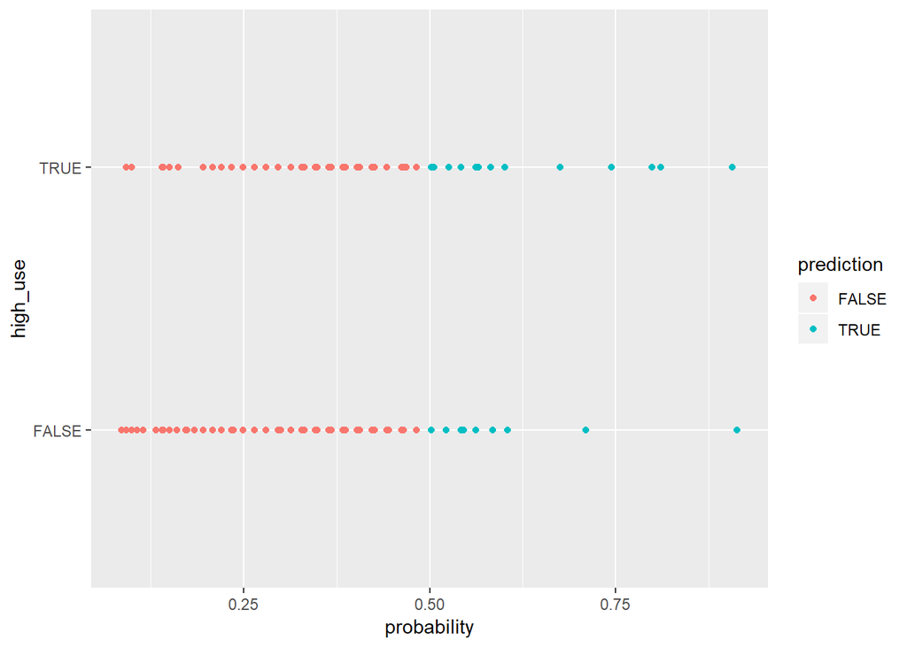

```r
g <- ggplot(alc2, aes(x = probability, y = high_use,col=prediction))

# define the geom as points and draw the plot
g+geom_point()
```

In this plot I can see both the actual values and the predictions. I have quite a lot of predictions of falses even though they were actually true. But is not as bad as predicting true even though they were falses in reality. falc

To quantify the goodness of my model I can count the proportion of incorrect predictions.

```r
# define a loss function (mean prediction error)
loss_func <- function(class, prob) {
  n_wrong <- abs(class - prob) > 0.5
  mean(n_wrong)
}

# call loss_func to compute the average number of wrong predictions
lfm3<-loss_func(class = alc2$high_use, prob = alc2$probability)
lfm3
```

```
## [1] 0.2827225
```

The result is 28 %. I could’ve counted that also from the second cross table (25 + 3 = 28 %). On my opinion that sounds like a lot but I guess it is still better than a simple guessing strategy. 72 % for correct predictions sounds better :)

The problem with this kind of model validation is that the model is asked to predict the same values that are used to create the model. This seems like a circular argument.

## Cross-validation

Another way of doing model validation is cross-validation. Here a proportion of the data is set aside as testing data and the model is fitted with training data (the rest) only. The resulting model is then fed with testing data to make predictions. The goodness of the model is then quantified as the proportion of correct predictions. This procedure is repeated several times so that the whole dataset has been used as testing data. If the cross-validation is 5-fold it means that the data are split into 5 proportions of which 1/5 is used as testing dataset one at a time. Which data to select as testing data can be random or for example spatially defined.

In R cross-validation can be done easily several times so I reapeat the following r code a couple of times:

```r
# K-fold cross-validation
library(boot)
cv <- cv.glm(data = alc2, cost = loss_func, glmfit = m, K = 10)

# average number of wrong predictions in the cross validation
cv$delta[1]
```

```
## [1] 0.2958115
```

## Comparing complicated and simple models with cross-validation metrics

Next I do a little exploration. I compare the performance of different logistic regression models (= different sets of predictors). I build models using 30, 19, 10 and 5 variables. I count training and testing errors for all the models and compare them.

```r
names(alc)
```

```
##  [1] "school"     "sex"        "age"        "address"    "famsize"
##  [6] "Pstatus"    "Medu"       "Fedu"       "Mjob"       "Fjob"
## [11] "reason"     "nursery"    "internet"   "guardian"   "traveltime"
## [16] "studytime"  "failures"   "schoolsup"  "famsup"     "paid"
## [21] "activities" "higher"     "romantic"   "famrel"     "freetime"
## [26] "goout"      "Dalc"       "Walc"       "health"     "absences"
## [31] "G1"         "G2"         "G3"         "alc_use"    "high_use"
```

```r
#select 30 variables
chooseM1<-c("age","high_use","famrel","absences","studytime","higher","activities","nursery", "internet","romantic","G3","address","Pstatus","Medu","Fedu","Mjob","Fjob", "reason","guardian","traveltime","failures","schoolsup", "famsup","paid", "freetime", "goout","health","school","sex","famsize")

alcM1<-select(alc,one_of(chooseM1))

#29 explaining variables
M1<-glm(high_use ~ school+higher+sex+age+ address+ famsize+ Medu+ Fedu+ Mjob+ Fjob+ reason+ nursery+ internet+ guardian+ traveltime+ failures+ schoolsup+ famsup+ paid+ freetime+ goout+ health+absences+studytime+famrel+activities+romantic+G3+Pstatus, data = alcM1, family = "binomial")

summary(M1)
```

```
##
## Call:
## glm(formula = high_use ~ school + higher + sex + age + address +
##     famsize + Medu + Fedu + Mjob + Fjob + reason + nursery +
##     internet + guardian + traveltime + failures + schoolsup +
##     famsup + paid + freetime + goout + health + absences + studytime +
##     famrel + activities + romantic + G3 + Pstatus, family = "binomial",
##     data = alcM1)
##
## Deviance Residuals:
##     Min       1Q   Median       3Q      Max
## -1.8741  -0.6724  -0.3610   0.4884   2.8798
##
## Coefficients:
##                  Estimate Std. Error z value Pr(>|z|)
## (Intercept)      -5.15777    3.12129  -1.652 0.098443 .
## schoolMS         -0.63603    0.54400  -1.169 0.242336
## higheryes        -0.09098    0.69925  -0.130 0.896481
## sexM              0.78325    0.32823   2.386 0.017019 *
## age               0.11618    0.14915   0.779 0.435985
## addressU         -0.79383    0.41437  -1.916 0.055398 .
## famsizeLE3        0.50910    0.32421   1.570 0.116356
## Medu              0.04330    0.22061   0.196 0.844378
## Fedu              0.17994    0.19563   0.920 0.357689
## Mjobhealth       -1.07131    0.76315  -1.404 0.160382
## Mjobother        -0.88901    0.49991  -1.778 0.075350 .
## Mjobservices     -0.87464    0.57337  -1.525 0.127151
## Mjobteacher      -0.28326    0.69357  -0.408 0.682977
## Fjobhealth        0.39818    1.19257   0.334 0.738465
## Fjobother         0.84816    0.86476   0.981 0.326685
## Fjobservices      1.42043    0.88485   1.605 0.108434
## Fjobteacher      -0.44976    1.03350  -0.435 0.663434
## reasonhome        0.46349    0.38041   1.218 0.223067
## reasonother       1.49313    0.54221   2.754 0.005891 **
## reasonreputation -0.07508    0.41153  -0.182 0.855246
## nurseryyes       -0.53587    0.36730  -1.459 0.144582
## internetyes       0.05745    0.45599   0.126 0.899736
## guardianmother   -0.80193    0.36635  -2.189 0.028601 *
## guardianother    -0.20393    0.79701  -0.256 0.798051
## traveltime        0.32510    0.23173   1.403 0.160644
```

[output cut: 9 more lines]

```
## famrel           -0.56897    0.16717  -3.404 0.000665 ***
## activitiesyes    -0.57526    0.30855  -1.864 0.062265 .
## romanticyes      -0.54641    0.33105  -1.651 0.098840 .
## G3                0.03375    0.05190   0.650 0.515575
## PstatusT         -0.36418    0.53795  -0.677 0.498421
## ---
## Signif. codes:  0 '***' 0.001 '**' 0.01 '*' 0.05 '.' 0.1 ' ' 1
##
## (Dispersion parameter for binomial family taken to be 1)
##
##     Null deviance: 465.68  on 381  degrees of freedom
## Residual deviance: 322.06  on 343  degrees of freedom
## AIC: 400.06
##
## Number of Fisher Scoring iterations: 5
```

```r
# predict() the probability of high_use
probabilities <- predict(M1, type = "response")

# add the predicted probabilities to 'alc'
alcM1 <- mutate(alcM1, probability = probabilities)

# use the probabilities to make a prediction of high_use
alcM1 <- mutate(alcM1, prediction = probability>0.5)

# call loss_func to compute the average number of wrong predictions
lfM1<-loss_func(class = alcM1$high_use, prob = alcM1$probability)

#cross-validation
cv <- cv.glm(data = alcM1, cost = loss_func, glmfit = M1, K = 10)

# average number of wrong predictions in the cross validation
cvM1<-cv$delta[1]

#####################################################################
#19 variables
chooseM2<-c("high_use","famrel","absences","studytime","activities","nursery", "romantic","address", "reason","guardian","traveltime","failures","paid", "freetime", "goout","health","school","sex","famsize")

alcM2<-select(alc,one_of(chooseM2))

#18 explaining variables
M2<-glm(high_use ~ school+sex+ address+ famsize+ reason+ nursery+ guardian+ traveltime+ failures+ paid+ freetime+ goout+health+absences+studytime+famrel+activities+romantic, data = alcM2, family = "binomial")

summary(M2)
```

```
##
## Call:
## glm(formula = high_use ~ school + sex + address + famsize + reason +
##     nursery + guardian + traveltime + failures + paid + freetime +
##     goout + health + absences + studytime + famrel + activities +
##     romantic, family = "binomial", data = alcM2)
##
## Deviance Residuals:
##     Min       1Q   Median       3Q      Max
## -1.9380  -0.6912  -0.3921   0.5668   2.7954
##
## Coefficients:
##                  Estimate Std. Error z value Pr(>|z|)
## (Intercept)      -2.24229    1.12611  -1.991 0.046461 *
## schoolMS         -0.36846    0.50370  -0.732 0.464470
## sexM              0.83559    0.30472   2.742 0.006104 **
## addressU         -0.86275    0.38198  -2.259 0.023905 *
## famsizeLE3        0.48723    0.30501   1.597 0.110173
## reasonhome        0.25059    0.36062   0.695 0.487133
## reasonother       1.11296    0.49712   2.239 0.025168 *
## reasonreputation -0.28950    0.37982  -0.762 0.445936
## nurseryyes       -0.41960    0.33948  -1.236 0.216463
## guardianmother   -0.72823    0.33009  -2.206 0.027373 *
## guardianother     0.10564    0.73524   0.144 0.885750
## traveltime        0.24550    0.21934   1.119 0.263024
## failures          0.17320    0.23209   0.746 0.455499
## paidyes           0.69857    0.29234   2.390 0.016870 *
## freetime          0.17239    0.15346   1.123 0.261274
## goout             0.84707    0.14158   5.983 2.19e-09 ***
## health            0.13123    0.10449   1.256 0.209140
## absences          0.09286    0.02425   3.830 0.000128 ***
## studytime        -0.25968    0.19222  -1.351 0.176709
## famrel           -0.48025    0.16126  -2.978 0.002900 **
## activitiesyes    -0.43744    0.28545  -1.532 0.125416
## romanticyes      -0.50198    0.30813  -1.629 0.103287
## ---
## Signif. codes:  0 '***' 0.001 '**' 0.01 '*' 0.05 '.' 0.1 ' ' 1
##
## (Dispersion parameter for binomial family taken to be 1)
##
##     Null deviance: 465.68  on 381  degrees of freedom
## Residual deviance: 338.38  on 360  degrees of freedom
## AIC: 382.38
##
## Number of Fisher Scoring iterations: 5
```

```r
# predict() the probability of high_use
probabilities <- predict(M2, type = "response")

# add the predicted probabilities to 'alc'
alcM2 <- mutate(alcM2, probability = probabilities)

# use the probabilities to make a prediction of high_use
alcM2 <- mutate(alcM2, prediction = probability>0.5)

# call loss_func to compute the average number of wrong predictions
lfM2<-loss_func(class = alcM2$high_use, prob = alcM2$probability)

cv <- cv.glm(data = alcM2, cost = loss_func, glmfit = M2, K = 10)

# average number of wrong predictions in the cross validation
cvM2<-cv$delta[1]

##########################################################################3
#10 variables
chooseM3<-c("high_use","famrel","absences","address", "reason","guardian","paid", "goout","sex","famsize")

alcM3<-select(alc,one_of(chooseM3))

#9 explaining variables
M3<-glm(high_use ~ sex+ address+ famsize+ reason+ guardian+  paid+  goout+absences+famrel, data = alcM3, family = "binomial")

summary(M3)
```

```
##
## Call:
## glm(formula = high_use ~ sex + address + famsize + reason + guardian +
##     paid + goout + absences + famrel, family = "binomial", data = alcM3)
##
## Deviance Residuals:
##     Min       1Q   Median       3Q      Max
## -1.9617  -0.7446  -0.4527   0.6513   2.8447
##
## Coefficients:
##                  Estimate Std. Error z value Pr(>|z|)
## (Intercept)      -2.13120    0.78716  -2.707 0.006780 **
## sexM              0.99325    0.27671   3.589 0.000331 ***
## addressU         -0.91297    0.33198  -2.750 0.005959 **
## famsizeLE3        0.44078    0.29197   1.510 0.131128
## reasonhome        0.15096    0.34314   0.440 0.659987
## reasonother       0.89873    0.46825   1.919 0.054940 .
## reasonreputation -0.53510    0.35986  -1.487 0.137017
## guardianmother   -0.70149    0.31737  -2.210 0.027085 *
## guardianother     0.33524    0.69442   0.483 0.629265
## paidyes           0.52463    0.27638   1.898 0.057669 .
## goout             0.86127    0.13257   6.497 8.21e-11 ***
## absences          0.09035    0.02330   3.877 0.000106 ***
## famrel           -0.43437    0.14964  -2.903 0.003699 **
## ---
## Signif. codes:  0 '***' 0.001 '**' 0.01 '*' 0.05 '.' 0.1 ' ' 1
##
## (Dispersion parameter for binomial family taken to be 1)
##
##     Null deviance: 465.68  on 381  degrees of freedom
## Residual deviance: 354.60  on 369  degrees of freedom
## AIC: 380.6
##
## Number of Fisher Scoring iterations: 5
```

```r
# predict() the probability of high_use
probabilities <- predict(M3, type = "response")

# add the predicted probabilities to 'alc'
alcM3 <- mutate(alcM3, probability = probabilities)

# use the probabilities to make a prediction of high_use
alcM3 <- mutate(alcM3, prediction = probability>0.5)

# call loss_func to compute the average number of wrong predictions
lfM3<-loss_func(class = alcM3$high_use, prob = alcM3$probability)

cv <- cv.glm(data = alcM3, cost = loss_func, glmfit = M3, K = 10)

# average number of wrong predictions in the cross validation
cvM3<-cv$delta[1]

##########################################################################3
#5 variables
chooseM4<-c("high_use","famrel","absences", "goout","sex")

alcM4<-select(alc,one_of(chooseM4))

#4 explaining variables
M4<-glm(high_use ~ sex+  goout+absences+famrel, data = alcM4, family = "binomial")

summary(M4)
```

```
##
## Call:
## glm(formula = high_use ~ sex + goout + absences + famrel, family = "binomial",
##     data = alcM4)
##
## Deviance Residuals:
##     Min       1Q   Median       3Q      Max
## -1.7151  -0.7820  -0.5137   0.7537   2.5463
##
## Coefficients:
##             Estimate Std. Error z value Pr(>|z|)
## (Intercept) -2.76826    0.66170  -4.184 2.87e-05 ***
## sexM         1.01234    0.25895   3.909 9.25e-05 ***
## goout        0.76761    0.12316   6.232 4.59e-10 ***
## absences     0.08168    0.02200   3.713 0.000205 ***
## famrel      -0.39378    0.14035  -2.806 0.005020 **
## ---
## Signif. codes:  0 '***' 0.001 '**' 0.01 '*' 0.05 '.' 0.1 ' ' 1
##
## (Dispersion parameter for binomial family taken to be 1)
##
##     Null deviance: 465.68  on 381  degrees of freedom
## Residual deviance: 379.81  on 377  degrees of freedom
## AIC: 389.81
##
## Number of Fisher Scoring iterations: 4
```

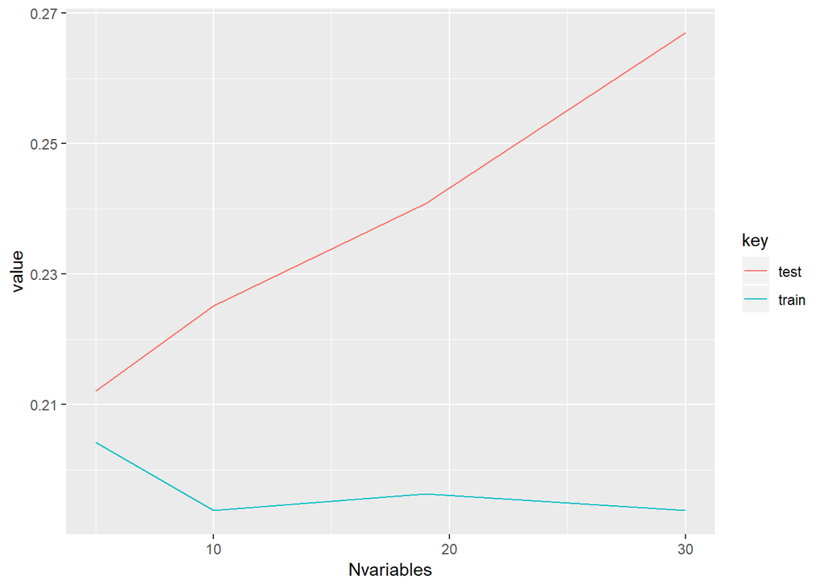

```r
# predict() the probability of high_use
probabilities <- predict(M4, type = "response")

# add the predicted probabilities to 'alc'
alcM4 <- mutate(alcM4, probability = probabilities)

# use the probabilities to make a prediction of high_use
alcM4 <- mutate(alcM4, prediction = probability>0.5)

# call loss_func to compute the average number of wrong predictions
lfM4<-loss_func(class = alcM4$high_use, prob = alcM4$probability)

cv <- cv.glm(data = alcM4, cost = loss_func, glmfit = M4, K = 10)

# average number of wrong predictions in the cross validation
cvM4<-cv$delta[1]

#create a data frame containing the number of variables and training and testing errors
Nvariables<-c(5,10,19,30)
errors<-as.data.frame(Nvariables)
errors$train=NA
errors[1, 2] = lfM4
errors[2, 2] = lfM3
errors[3, 2] = lfM2
errors[4, 2] = lfM1
errors$test=NA
errors[1, 3] = cvM4
errors[2, 3] = cvM3
errors[3, 3] = cvM2
errors[4, 3] = cvM1

#plot the results
dfplot <- errors %>% gather(key, value, -Nvariables)

ggplot(dfplot, mapping = aes(x = Nvariables, y = value, color = key) ) + geom_line()
```

It seems that reducing the number of explaining variables from 30 to 5 has little effect on training errors whereas for testing errors it has a significant negative effect. It reduces the testing error and models with less variables seem to give more accurate predictions.

I’m not sure what exactly I can interpret from this result because as I reduced the number of explaining variables I dropped them based on their statistical insignificance.